# Human Development Analysis

Jenn Griffiths’s Data Science Portfolio

```
In an Introduction, describe your motivation for choosing the general topic of your portfolio.
Identify your initial data set that you will be using. The data set should have at least:
    at least 1000 observations
    at least 10 variables
    ...of which at least 3 are categorical
    ...and at least 7 are continuous
Describe your source, using critical analysis to assess the quality (and possible limitations) of it
Document your variables and describe in plain language what they mean and how they are represented
Document any manipulations you make to clean your data and organize it as Tidy Data as best you can prepare it for data analysis and modeling
Summarize your data using descriptive statistics, along with visualizations (with accompanying interpretations) that help explore what possible insights you might investigate.
Finally, describe what research questions you hope to explore in later phases, along with potential social & ethical implications of your work. For help identifying and phrasing research questions, see How to Write a Research Question
```

# Install Libraries

These libraries allow us to use the various functions within this document

```r
#install.packages("tidyverse")
library(tidyverse)
library(readr)
library(dplyr)
library(tidyr)
library(ggplot2)
```

# Load the Data

Loading the original data into the analysis environment. The original data will not be altered. Versions of the data are created in this environment which can be freely manipulated. If an alteration, such as a removal of a column, was a mistake - one can always reload the original data.

```r
Indicators <- read_csv("Data/Indicators.csv")
```

# View the Dataframes

This function will show us the top 6 rows of the dataframe in order to give us an idea of the structure of table.

```r
head(Indicators)
```

| dimension | indicator_id | indicator_name | iso3 | country_name | 1990 | 1991 | 1992 | 1993 | 1994 | 1995 | 1996 | 1997 | 1998 | 1999 | 2000 | 2001 | 2002 | 2003 | 2004 | 2005 | 2006 | 2007 | 2008 | 2009 | 2010 | 2011 | 2012 | 2013 | 2014 | … |
| --- | --- | --- | --- | --- | --- | --- | --- | --- | --- | --- | --- | --- | --- | --- | --- | --- | --- | --- | --- | --- | --- | --- | --- | --- | --- | --- | --- | --- | --- | --- |
| Composite indices | 146206 | HDI rank | AFG | Afghanistan | NA | NA | NA | NA | NA | NA | NA | NA | NA | NA | NA | NA | NA | NA | NA | NA | NA | NA | NA | NA | NA | NA | NA | NA | NA | … |
| Composite indices | 146206 | HDI rank | ALB | Albania | NA | NA | NA | NA | NA | NA | NA | NA | NA | NA | NA | NA | NA | NA | NA | NA | NA | NA | NA | NA | NA | NA | NA | NA | NA | … |
| Composite indices | 146206 | HDI rank | DZA | Algeria | NA | NA | NA | NA | NA | NA | NA | NA | NA | NA | NA | NA | NA | NA | NA | NA | NA | NA | NA | NA | NA | NA | NA | NA | NA | … |
| Composite indices | 146206 | HDI rank | AND | Andorra | NA | NA | NA | NA | NA | NA | NA | NA | NA | NA | NA | NA | NA | NA | NA | NA | NA | NA | NA | NA | NA | NA | NA | NA | NA | … |
| Composite indices | 146206 | HDI rank | AGO | Angola | NA | NA | NA | NA | NA | NA | NA | NA | NA | NA | NA | NA | NA | NA | NA | NA | NA | NA | NA | NA | NA | NA | NA | NA | NA | … |
| Composite indices | 146206 | HDI rank | ATG | Antigua and Barbuda | NA | NA | NA | NA | NA | NA | NA | NA | NA | NA | NA | NA | NA | NA | NA | NA | NA | NA | NA | NA | NA | NA | NA | NA | NA | … |

# Inspecting the Data

```r
#Count of rows
nrow(Indicators)
```

```
[1] 25636
```

```r
#Count of columns
ncol(Indicators)
```

```
[1] 34
```

```r
#List of the columns in the dataframe
names(Indicators)
```

```
 [1] "dimension"      "indicator_id"
 [3] "indicator_name" "iso3"
 [5] "country_name"   "1990"
 [7] "1991"           "1992"
 [9] "1993"           "1994"
[11] "1995"           "1996"
[13] "1997"           "1998"
[15] "1999"           "2000"
[17] "2001"           "2002"
[19] "2003"           "2004"
[21] "2005"           "2006"
[23] "2007"           "2008"
[25] "2009"           "2010"
[27] "2011"           "2012"
[29] "2013"           "2014"
[31] "2015"           "2016"
[33] "2017"           "9999"
```

# Tidy The Data

Tidying the data is an important part of preparing your data for analysis. Making your data tidy can be time consuming but it makes the format of your data consistent and easier to manage when you’re analyzing the data.

### Categorical Varibles

Change variable ‘dimension’ to a categorical variable, meaning there are only a certain number of values it could possibly be. This will help with analysis later.

```r
Indicators$dimension <-as.factor(Indicators$dimension)
#Display number of levels in 'dimension' variable
nlevels(Indicators$dimension)
```

```
[1] 14
```

> Change variable ‘indicator_name’ to a categorical variable

```r
Indicators$indicator_name <-as.factor(Indicators$indicator_name)
#Display levels in 'indicator_name' variable
nlevels(Indicators$indicator_name)
```

```
[1] 157
```

> Change variable ‘country_name’ to a categorical variable

```r
Indicators$country_name <-as.factor(Indicators$country_name)

#Display levels in 'country_name' variable
nlevels(Indicators$country_name)
```

[output not shown]

> Change variable ‘indicator_id’ to a categorical variable

```r
Indicators$indicator_id <-as.factor(Indicators$indicator_id)
```

> Change variable ‘iso3’ to a categorical variable

```r
Indicators$iso3 <-as.factor(Indicators$iso3)
```

### Gather year columns

An important feature of tidy data is that “each variable must have its own column” As in the variable years should be in a single column. This is done because it makes transforming the data a much smoother process.

```r
Indicators <-gather(Indicators, key = Years, "1990", "1991", "1992", "1993", "1994", "1995", "1996", "1997", "1998","1999", "2000", "2001", "2002","2003","2004","2005","2006", "2007","2008","2009","2010","2011","2012","2013","2014","2015", "2016", "2017","9999")
#rename last column to rating
colnames(Indicators)[colnames(Indicators) == "1990" ] <- "HDI_value"
```

# Subset the data based on ‘dimensions’ category

To break up the data by ‘dimesions’, we mush take subsets of the original table. It is good practice to have each table be one thing, rather than a collection of everything. Dimensions in this dataset are the category under which the Human Development Index is scored. For example dimensions include education, health, demographics, and so on.

```r
Composite_indices <- subset(Indicators, dimension == "Composite indices" )
Demography <- subset(Indicators, dimension == "Demography" )
Education <- subset(Indicators, dimension == "Education" )
Environmental_sustainability <- subset(Indicators, dimension == "Environmental sustainability" )
Gender <- subset(Indicators, dimension == "Gender" )
Health <- subset(Indicators, dimension == "Health" )
Human_Security <- subset(Indicators, dimension == "Human Security" )
Income_resources <- subset(Indicators, dimension == "Income/composition of resources" )
Inequality <- subset(Indicators, dimension == "Inequality" )
Mobility_communication <- subset(Indicators, dimension == "Mobility and communication" )
Poverty <- subset(Indicators, dimension == "Poverty" )
Sustainability <- subset(Indicators, dimension == "Socio-economic sustainability" )
Financial_flows <- subset(Indicators, dimension == "Trade and financial flows" )
Work_vulnerability <- subset(Indicators, dimension == "Work, employment and vulnerability" )
```

# Creating Tibbles

A tibble is a subset table from a larger table (Rows and columns of data). Creating a tibble for each ’dimension, or category for which the Humand Development Index was calculated. Here we are creating a tibble from each of the subset tables.

```r
  #Composite Indices Tibble
Tib_CompositeIndices <- tibble(indicator = Composite_indices$indicator_name, country = Composite_indices$country_name, year = Composite_indices$Years, HDI_value = Composite_indices$HDI_value)
  #Demography Tibble
Tib_Demography <- tibble(indicator = Demography$indicator_name, country = Demography$country_name, year = Demography$Years, HDI_value = Demography$HDI_value)
  #Education Tibble
Tib_Education <- tibble(indicator = Education$indicator_name, country = Education$country_name, year = Education$Years, HDI_value = Education$HDI_value)
  #Environmenta lSustainability Tibble
Tib_EnvironmentalSustainability <- tibble(indicator = Environmental_sustainability$indicator_name, country = Environmental_sustainability$country_name, year = Environmental_sustainability$Years, HDI_value = Environmental_sustainability$HDI_value)
  #Gender Tibble
Tib_Gender <- tibble(indicator = Gender$indicator_name, country = Gender$country_name, year = Gender$Years, HDI_value = Gender$HDI_value)
  #Health Tibble
Tib_Health <- tibble(indicator = Health$indicator_name, country = Health$country_name, year = Health$Years, HDI_value = Health$HDI_value)
  #Human Security Tibble
Tib_HumanSecurity <- tibble(indicator = Human_Security$indicator_name, country = Human_Security$country_name, year = Human_Security$Years, HDI_value = Human_Security$HDI_value)
  #Income Resources Tibble
Tib_IncomeResources <- tibble(indicator = Income_resources$indicator_name, country = Income_resources$country_name, year = Income_resources$Years, HDI_value = Income_resources$HDI_value)
  #Inequality Tibble
Tib_Inequality <- tibble(indicator = Inequality$indicator_name, country = Inequality$country_name, year = Inequality$Years, HDI_value = Inequality$HDI_value)
  #Mobility Communication Tibble
Tib_MobilityCommunication <- tibble(indicator = Mobility_communication$indicator_name, country = Mobility_communication$country_name, year = Mobility_communication$Years, HDI_value = Mobility_communication$HDI_value)
  #Poverty Tibble
Tib_Poverty <- tibble(indicator = Poverty$indicator_name, country = Poverty$country_name, year = Poverty$Years, HDI_value = Poverty$HDI_value)
  #Sustainability Tibble
Tib_Sustainability <- tibble(indicator = Sustainability$indicator_name, country = Sustainability$country_name, year = Sustainability$Years, HDI_value = Sustainability$HDI_value)
  #Financial Flows Tibble
Tib_FinancialFlows <- tibble(indicator = Financial_flows$indicator_name, country = Financial_flows$country_name, year = Financial_flows$Years, HDI_value = Financial_flows$HDI_value)
  #Work Vulnerability Tibble
Tib_WorkVulnerability <- tibble(indicator = Work_vulnerability$indicator_name, country = Work_vulnerability$country_name, year = Work_vulnerability$Years, HDI_value = Work_vulnerability$HDI_value)
```

> There are still a lot of missing values (NA in a cell). For now we will leave them in, but an important tool to use when analyzing the data is the function to remove NA vlues from the calculations: >na.rm = TRUE

# Now Its Time For STEP ZERO: Plot The Data

Nothing gives you a better perspective on your data than plotting your data.

### Bar Chart accross 2 variable

At first glace the two tall bars in the center look as though there is something weird going on here. In looking into the tibble, it is evident that the HDI_value is scoring each indicator with different units. Most scores are in context of percentages, whereas the two tall bars are in terms of headcounts of certain population groups. This leads to the conclusion that these tibbles need to be sliced again base on the indicators in order for the HDI_values in a tibble to be in the same units.

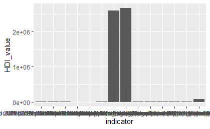

```r
ggplot(Tib_Poverty, aes(indicator, HDI_value) ) + geom_col() + geom_path(colour = "red", na.rm = TRUE)
```

### Bar Chart

Looking at distributions of a single variable The assumption would be that there is an even spread of the amount of indicators across the dataset but here we see there a subtle dip the a rise at the far right of the bar graph.

Is this due to the missing data being removed? Or possibly some other reason for the uneven distribution?

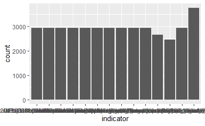

```r
chart<- ggplot(Tib_Poverty, aes(indicator), na.rm = TRUE)
chart + geom_bar()
```